# Data visualisation with R

Session Two

Akos Mate

2021 March

# 1 Before we start

What we missed during the previous session is how to export your `ggplot` chart. For this, use the `ggsave()` function, where you can specify the resultion with `dpi` (no more low resolution exports!), and the dimensions of the exported plot and the file format as well. As a default it saves the last `ggplot` that you created, but you can always store your plot in an object and save a given plot explicitly. See the example below.

```r
my_plot <- ggplot(data, aes(x, y)) +
    geom_line()

ggsave(my_plot, filename = "save/here/my_plot.png", dpi = 320, width = 120, height = 120)
```

# 2 Visualizing hypothesis tests

First things first, let’s load our needed packages.

```r
# data import and cleaning
library(readr)
library(dplyr)
library(haven)

# statistical modeling
library(broom) # extracting model information

# practice data
library(gapminder)
library(eurostat)
library(maps)

# general data visualisation
library(ggplot2)
library(ggridges)
library(ggthemes)
library(gghighlight)
library(GGally)
library(ggfortify)
library(factoextra)

# network related packages
library(ggraph)
library(tidygraph)
```

## 2.1 t-test

The t-test is a simple, yet powerful statistical technique to check whether two sample means differ from each other statistically significantly. For experimental setups you can examine if your treatment caused a statistically significant effect compared to your control group for example. The validity of the test is based on the assumptions that our sample is randomly selected from the population and people are randomly distributed between the treatment and control groups as well.

Let’s look at the survey data of the European Social Survey. It contains a select few variables from the Hungarian survey. Let’s further trim the dataset, so we only have what we need right now. We will also eliminate the “No Response”, “Don’t Know” codes, by filtering these values out. Note: in a real analysis these still carry information, but for us they would pose needless complications. We also create a factor variable from the gender one, by specifying the levels and corresponding labels.

```r
ess_data <- read_csv("data/ESS_Hun_7.csv")
ess_sample <- ess_data %>%
    select(cntry, tvpol:gndr) %>%
    filter(tvpol < 66, polintr < 7, trstlgl < 11, gndr < 3) %>%
    mutate(gndr = factor(gndr, levels = c(1,2), labels = c("male", "female")))

glimpse(ess_sample)
```

```
#> Rows: 1,596
#> Columns: 6
#> $ cntry   <chr> "HU", "HU", "HU", "HU", "HU", "HU", "HU", "HU", "HU", "HU", "HU", "HU...
#> $ tvpol   <dbl> 1, 1, 1, 2, 1, 1, 0, 2, 1, 1, 1, 1, 2, 1, 2, 2, 1, 2, 1, 1, 2, 4, 2, ...
#> $ polintr <dbl> 4, 4, 4, 1, 4, 3, 3, 4, 2, 3, 4, 3, 4, 4, 3, 2, 4, 4, 3, 3, 3, 4, 3, ...
#> $ trstlgl <dbl> 6, 0, 0, 10, 0, 0, 7, 5, 2, 4, 6, 0, 3, 2, 5, 10, 5, 5, 5, 2, 5, 2, 3...
#> $ mmbprty <lgl> NA, NA, NA, NA, NA, NA, NA, NA, NA, NA, NA, NA, NA, NA, NA, NA, NA, N...
#> $ gndr    <fct> female, male, male, female, female, female, female, female, male, mal...
```

In R a t-test is implemented in the `t.test()` function. As a minimum, for an independent samples t-test, you just need to provide it with two vectors of data values as the first two arguments. It also accepts input in the form of a formula, which might be more convenient in some occasions.

So let’s see if men and women differ in political interest. Let’s put the results of the test into an object called `polintr_test` and print them by just calling the name of the object.

```r
polintr_test <- t.test(polintr ~ gndr, data = ess_sample)

polintr_test
```

```
#>
#>  Welch Two Sample t-test
#>
#> data:  polintr by gndr
#> t = -4.7959, df = 1425.2, p-value = 1.789e-06
#> alternative hypothesis: true difference in means is not equal to 0
#> 95 percent confidence interval:
#>  -0.2937204 -0.1231945
#> sample estimates:
#>   mean in group male mean in group female
#>             2.898529             3.106987
```

Visualizing the t-test can be done with representing the group means with points and plotting errorbars on top of them. Let’s demonstrate this on the political interest. In the following code I also chain together some `dplyr` action and `ggplot2`. We will use the `geom_errorban()` function. To measure the uncertainty around our point estimates we are calculating the standard errors. We use the following formula:

$$SE = \frac{\sigma}{\sqrt{n}}$$

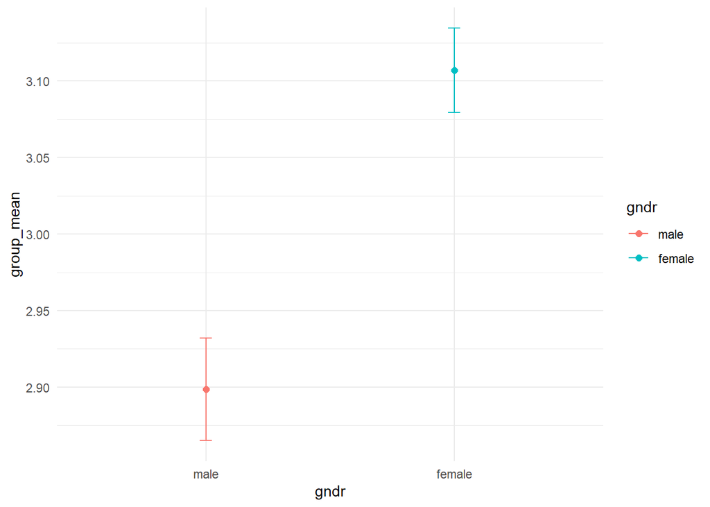

```r
ess_sample %>%
    group_by(gndr) %>%
    summarise(group_mean = mean(polintr, na.rm = TRUE), se = sd(polintr, na.rm = TRUE) / sqrt(length(polintr))) %>%
    ggplot(aes(x = gndr, y = group_mean, color = gndr)) +
    geom_point(size = 2) +
    geom_errorbar(aes(ymin = group_mean - se, ymax = group_mean + se), width=.05) +
    #scale_y_continuous(limits = c(0, 3.5)) +
    theme_minimal()
```

Note the commented out `scale_y_continous`!

A more traditional way is to plot barcharts with the errorbars on top of them.

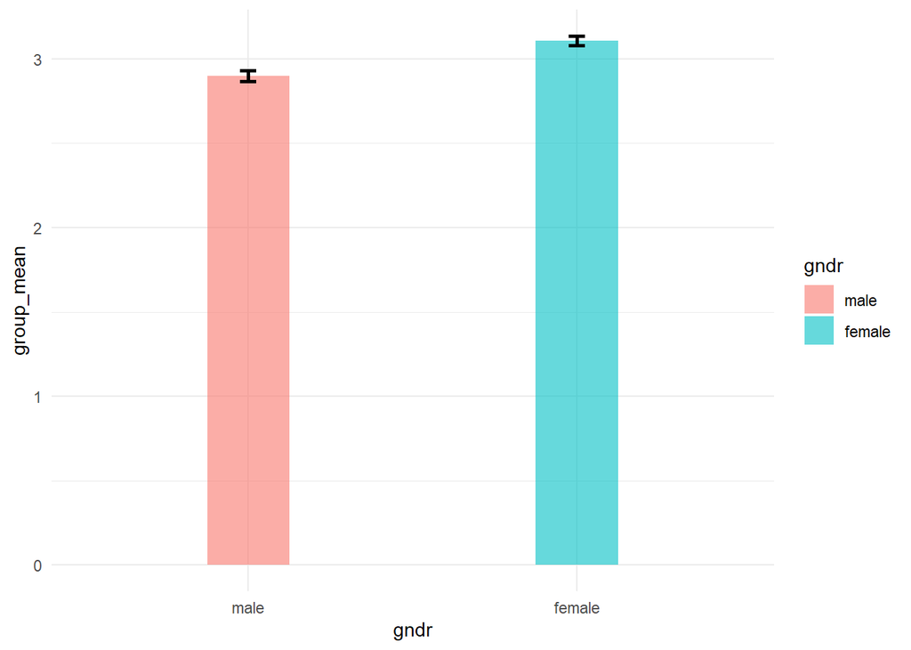

```r
ess_sample %>%
    group_by(gndr) %>%
    summarise(group_mean = mean(polintr, na.rm = TRUE), se = sd(polintr, na.rm = TRUE) / sqrt(length(polintr))) %>%
    ggplot(aes(x = gndr, y = group_mean, fill = gndr)) +
    geom_bar(stat="identity", width = 0.25, alpha = 0.6) +
    geom_errorbar(aes(ymin = group_mean - se, ymax = group_mean + se), width=.05, size = 1) +
    theme_minimal()
```

## 2.2 ANOVA

If we are curious about the difference between more than two sample means, we can use the Analysis of Variance test. The following is a simple one-way analysis of variance – with one response variable and one explanatory variable. There are many other versions of ANOVA, that we will not have the chance to look at here.

We are going to use the `airquality` data.

```r
anova1 <- aov(Temp ~ Month, data=airquality)

anova1
```

```
#> Call:
#>    aov(formula = Temp ~ Month, data = airquality)
#>
#> Terms:
#>                     Month Residuals
#> Sum of Squares   2413.042 11204.840
#> Deg. of Freedom         1       151
#>
#> Residual standard error: 8.614188
#> Estimated effects may be unbalanced
```

```r
summary(anova1)
```

```
#>              Df Sum Sq Mean Sq F value   Pr(>F)
#> Month         1   2413  2413.0   32.52 6.03e-08 ***
#> Residuals   151  11205    74.2
#> ---
#> Signif. codes:  0 '***' 0.001 '**' 0.01 '*' 0.05 '.' 0.1 ' ' 1
```

The most important information to look for here is the F value and the associated p-value (Pr(>F)). If the latter is less than our threshold for statistical significance (0.05 in our case), we can conclude that there is a statistically significant difference between the means of the groups. In our case the value is well below our threshold, which means that we can reject our null hypothesis of no difference between the means.

If we would want to visualize this, we could plot the group means with the error bars. First, we summarize our data then use `ggplot`.

To change things up, we are going to use the `geom_pointrange()` function to illustrate the uncertainty around our point estimates.

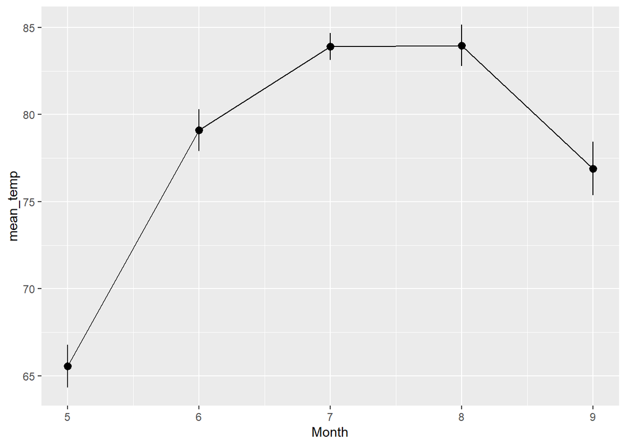

```r
anova_sum <- airquality %>%
  group_by(Month) %>%
  summarise(mean_temp = mean(Temp), sd = sd(Temp), se = sd/sqrt(length(Temp)))


ggplot(data = anova_sum,
       mapping = aes(x = Month,
                     y = mean_temp)) +
  geom_pointrange(aes(ymin = mean_temp - se, ymax = mean_temp + se)) +
  geom_line() +
  geom_point() +
  theme(legend.position = "none")
```

## 2.3 Correlation

Perhaps the most common approach to look into associations between variables is the correlation. There are also different types of correlation, here we will be talking about the Pearson correlation, which is what is usually thought of when people speak about correlation. It shows the association between two continuous variables and is implemented in R in the `cor()` and `cor.test()` functions. The first simply calculates the value of the correlation coefficient, the second also performs a statistical test to tell you if the correlation is statistically different from 0.

We will use the, by now, well known gapminder dataset for both the correlation and both the regression analysis examples. The only modifications we will make to the data is to create a cross-section of it, by limiting all observations to the year 2007.

```r
gapminder_cs <- gapminder %>%
    filter(year == 2007)


glimpse(gapminder_cs)
```

```
#> Rows: 142
#> Columns: 6
#> $ country   <fct> "Afghanistan", "Albania", "Algeria", "Angola", "Argentina", "Austra...
#> $ continent <fct> Asia, Europe, Africa, Africa, Americas, Oceania, Europe, Asia, Asia...
#> $ year      <int> 2007, 2007, 2007, 2007, 2007, 2007, 2007, 2007, 2007, 2007, 2007, 2...
#> $ lifeExp   <dbl> 43.828, 76.423, 72.301, 42.731, 75.320, 81.235, 79.829, 75.635, 64....
#> $ pop       <int> 31889923, 3600523, 33333216, 12420476, 40301927, 20434176, 8199783,...
#> $ gdpPercap <dbl> 974.5803, 5937.0295, 6223.3675, 4797.2313, 12779.3796, 34435.3674, ...
```

The `cor()` function is useful, because it provides the possibility to look at many variables at once. So let’s have a look at all the correlations between the variables in the dataset. The `cor()` function is picky about missing data and therefore we have to tell it to drop the cases with missing values on a variable for the calculation of a specific correlation. The `"pairwise.complete"` option tells it to use for each correlation the set of observations that complete.

In the function call, I specify that I want the correlation between the last three variables.

```r
cor(gapminder_cs[, 4:6], use = "pairwise.complete", method = "pearson")
```

```
#>              lifeExp         pop  gdpPercap
#> lifeExp   1.00000000  0.04755312  0.6786624
#> pop       0.04755312  1.00000000 -0.0556756
#> gdpPercap 0.67866240 -0.05567560  1.0000000
```

We can plot a correlation heatmap with the `GGally::ggcorr` function of the `GGally` ggplot extension package.

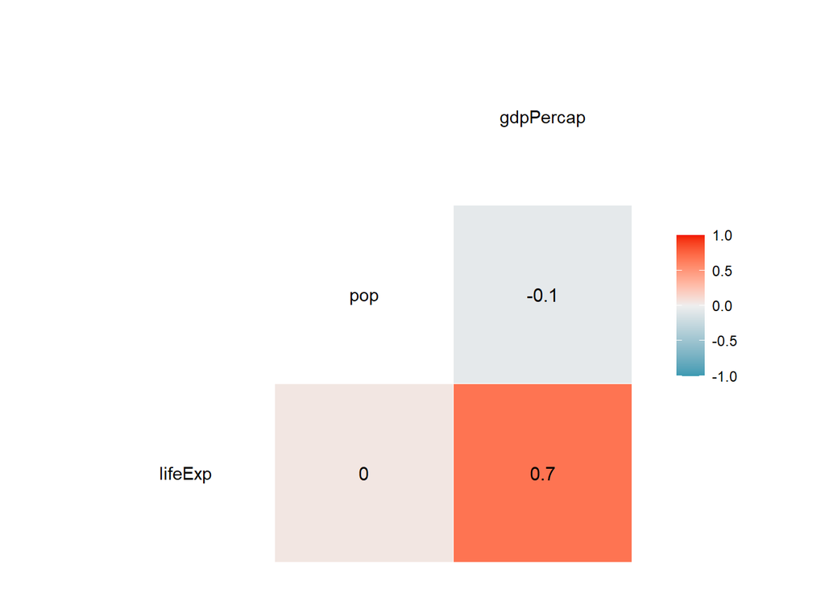

```r
ggcorr(gapminder_cs[, 4:6], label = TRUE)
```

## 2.4 Regression

Out of the example data that we have had, let’s try to model the life expectancy in certain countries from the `gapminder` dataset as a function of the GDP per capita, population and spatial features (continent). We will fit a linear model and estimate it with OLS.

```r
reg1 <- lm(lifeExp ~ gdpPercap + pop + continent, data = gapminder_cs)

summary(reg1)
```

```
#>
#> Call:
#> lm(formula = lifeExp ~ gdpPercap + pop + continent, data = gapminder_cs)
#>
#> Residuals:
#>      Min       1Q   Median       3Q      Max
#> -22.8199  -2.8905   0.1574   2.9046  20.0585
#>
#> Coefficients:
#>                    Estimate Std. Error t value Pr(>|t|)
#> (Intercept)       5.371e+01  9.356e-01  57.413  < 2e-16 ***
#> gdpPercap         3.479e-04  5.717e-05   6.086 1.13e-08 ***
#> pop               9.586e-10  3.926e-09   0.244  0.80747
#> continentAmericas 1.603e+01  1.671e+00   9.592  < 2e-16 ***
#> continentAsia     1.256e+01  1.621e+00   7.751 1.97e-12 ***
#> continentEurope   1.520e+01  1.966e+00   7.730 2.20e-12 ***
#> continentOceania  1.662e+01  4.993e+00   3.329  0.00112 **
#> ---
#> Signif. codes:  0 '***' 0.001 '**' 0.01 '*' 0.05 '.' 0.1 ' ' 1
#>
#> Residual standard error: 6.597 on 135 degrees of freedom
#> Multiple R-squared:  0.7141, Adjusted R-squared:  0.7014
#> F-statistic:  56.2 on 6 and 135 DF,  p-value: < 2.2e-16
```

For further diagnostic plots, we can use the `ggfortify` extension of ggplot. This allows us to quickly plot key diagnostics and if needed use the `ggplot` syntax to change elements of the plots. The `ggfortify::autoplot()` figures everything out for us. You can select which plots you need with the `which = 1:6` option.

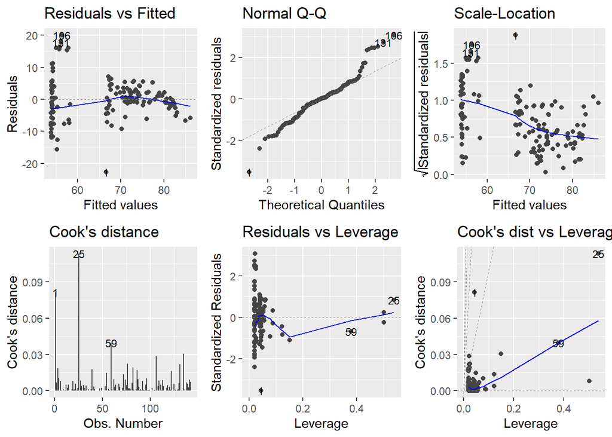

```r
autoplot(reg1, which = 1:6, ncol = 3, label.size = 3)
```

## 2.5 Objects and the `broom` package

Let’s dig into our regression objects. We’ll stick to the `reg1` object for now. A quick way to look into our object is the `str()` function.

```r
str(reg1)
```

```
#> List of 13
#>  $ coefficients : Named num [1:7] 5.37e+01 3.48e-04 9.59e-10 1.60e+01 1.26e+01 ...
#>   ..- attr(*, "names")= chr [1:7] "(Intercept)" "gdpPercap" "pop" "continentAmericas" ...
#>  $ residuals    : Named num [1:142] -22.82 5.44 16.39 -12.66 1.09 ...
#>   ..- attr(*, "names")= chr [1:142] "1" "2" "3" "4" ...
#>  $ effects      : Named num [1:142] -798.5 97.3 12.3 39.1 29.5 ...
#>   ..- attr(*, "names")= chr [1:142] "(Intercept)" "gdpPercap" "pop" "continentAmericas" ...
#>  $ rank         : int 7
#>  $ fitted.values: Named num [1:142] 66.6 71 55.9 55.4 74.2 ...
#>   ..- attr(*, "names")= chr [1:142] "1" "2" "3" "4" ...
#>  $ assign       : int [1:7] 0 1 2 3 3 3 3
#>  $ qr           :List of 5
#>   ..$ qr   : num [1:142, 1:7] -11.9164 0.0839 0.0839 0.0839 0.0839 ...
#>   .. ..- attr(*, "dimnames")=List of 2
#>   .. .. ..$ : chr [1:142] "1" "2" "3" "4" ...
#>   .. .. ..$ : chr [1:7] "(Intercept)" "gdpPercap" "pop" "continentAmericas" ...
#>   .. ..- attr(*, "assign")= int [1:7] 0 1 2 3 3 3 3
#>   .. ..- attr(*, "contrasts")=List of 1
#>   .. .. ..$ continent: chr "contr.treatment"
#>   ..$ qraux: num [1:7] 1.08 1.03 1.01 1.04 1.03 ...
#>   ..$ pivot: int [1:7] 1 2 3 4 5 6 7
#>   ..$ tol  : num 1e-07
#>   ..$ rank : int 7
#>   ..- attr(*, "class")= chr "qr"
#>  $ df.residual  : int 135
#>  $ contrasts    :List of 1
#>   ..$ continent: chr "contr.treatment"
#>  $ xlevels      :List of 1
#>   ..$ continent: chr [1:5] "Africa" "Americas" "Asia" "Europe" ...
#>  $ call         : language lm(formula = lifeExp ~ gdpPercap + pop + continent, data = gapminder_cs)
#>  $ terms        :Classes 'terms', 'formula'  language lifeExp ~ gdpPercap + pop + continent
#>   .. ..- attr(*, "variables")= language list(lifeExp, gdpPercap, pop, continent)
#>   .. ..- attr(*, "factors")= int [1:4, 1:3] 0 1 0 0 0 0 1 0 0 0 ...
#>   .. .. ..- attr(*, "dimnames")=List of 2
#>   .. .. .. ..$ : chr [1:4] "lifeExp" "gdpPercap" "pop" "continent"
#>   .. .. .. ..$ : chr [1:3] "gdpPercap" "pop" "continent"
#>   .. ..- attr(*, "term.labels")= chr [1:3] "gdpPercap" "pop" "continent"
#>   .. ..- attr(*, "order")= int [1:3] 1 1 1
#>   .. ..- attr(*, "intercept")= int 1
#>   .. ..- attr(*, "response")= int 1
```

[output cut: 9 more lines]

```
#>   ..- attr(*, "terms")=Classes 'terms', 'formula'  language lifeExp ~ gdpPercap + pop + continent
#>   .. .. ..- attr(*, "variables")= language list(lifeExp, gdpPercap, pop, continent)
#>   .. .. ..- attr(*, "factors")= int [1:4, 1:3] 0 1 0 0 0 0 1 0 0 0 ...
#>   .. .. .. ..- attr(*, "dimnames")=List of 2
#>   .. .. .. .. ..$ : chr [1:4] "lifeExp" "gdpPercap" "pop" "continent"
#>   .. .. .. .. ..$ : chr [1:3] "gdpPercap" "pop" "continent"
#>   .. .. ..- attr(*, "term.labels")= chr [1:3] "gdpPercap" "pop" "continent"
#>   .. .. ..- attr(*, "order")= int [1:3] 1 1 1
#>   .. .. ..- attr(*, "intercept")= int 1
#>   .. .. ..- attr(*, "response")= int 1
#>   .. .. ..- attr(*, ".Environment")=<environment: R_GlobalEnv>
#>   .. .. ..- attr(*, "predvars")= language list(lifeExp, gdpPercap, pop, continent)
#>   .. .. ..- attr(*, "dataClasses")= Named chr [1:4] "numeric" "numeric" "numeric" "factor"
#>   .. .. .. ..- attr(*, "names")= chr [1:4] "lifeExp" "gdpPercap" "pop" "continent"
#>  - attr(*, "class")= chr "lm"
```

Well, this does look cluttered. As our object is basically a list, we can dig into it, with the usual methods.

```r
reg1$coefficients
```

```
#>       (Intercept)         gdpPercap               pop continentAmericas     continentAsia
#>      5.371419e+01      3.479124e-04      9.586008e-10      1.603137e+01      1.256404e+01
#>   continentEurope  continentOceania
#>      1.519892e+01      1.662221e+01
```

There are other ways to access this information, with built in functions. For example, using the `coef()`.

```r
coef(reg1)
```

```
#>       (Intercept)         gdpPercap               pop continentAmericas     continentAsia
#>      5.371419e+01      3.479124e-04      9.586008e-10      1.603137e+01      1.256404e+01
#>   continentEurope  continentOceania
#>      1.519892e+01      1.662221e+01
```

It is also useful to keep in mind that if you call the `summary()` function on a model object, then this creates a new kind of an object, also with its own internal structure, that might have useful information for us.

```r
summary_reg1 <- summary(reg1)

summary_reg1
```

```
#>
#> Call:
#> lm(formula = lifeExp ~ gdpPercap + pop + continent, data = gapminder_cs)
#>
#> Residuals:
#>      Min       1Q   Median       3Q      Max
#> -22.8199  -2.8905   0.1574   2.9046  20.0585
#>
#> Coefficients:
#>                    Estimate Std. Error t value Pr(>|t|)
#> (Intercept)       5.371e+01  9.356e-01  57.413  < 2e-16 ***
#> gdpPercap         3.479e-04  5.717e-05   6.086 1.13e-08 ***
#> pop               9.586e-10  3.926e-09   0.244  0.80747
#> continentAmericas 1.603e+01  1.671e+00   9.592  < 2e-16 ***
#> continentAsia     1.256e+01  1.621e+00   7.751 1.97e-12 ***
#> continentEurope   1.520e+01  1.966e+00   7.730 2.20e-12 ***
#> continentOceania  1.662e+01  4.993e+00   3.329  0.00112 **
#> ---
#> Signif. codes:  0 '***' 0.001 '**' 0.01 '*' 0.05 '.' 0.1 ' ' 1
#>
#> Residual standard error: 6.597 on 135 degrees of freedom
#> Multiple R-squared:  0.7141, Adjusted R-squared:  0.7014
#> F-statistic:  56.2 on 6 and 135 DF,  p-value: < 2.2e-16
```

### 2.5.1 Using `broom`

To make the somewhat messy regression output more “tidy”, we’ll use the `broom` package’s `broom::tidy()` function. It creates a data frame from our regression object with the estimate, se, f statistics and p.value columns, and each IV as row.

```r
reg1_tidy <- tidy(reg1, conf.int = TRUE)

reg1_tidy
```

```
#> # A tibble: 7 x 7
#>   term              estimate     std.error statistic  p.value conf.low conf.high
#>   <chr>                <dbl>         <dbl>     <dbl>    <dbl>    <dbl>     <dbl>
#> 1 (Intercept)       5.37e+ 1 0.936            57.4   9.97e-97  5.19e+1   5.56e+1
#> 2 gdpPercap         3.48e- 4 0.0000572         6.09  1.13e- 8  2.35e-4   4.61e-4
#> 3 pop               9.59e-10 0.00000000393     0.244 8.07e- 1 -6.81e-9   8.72e-9
#> 4 continentAmericas 1.60e+ 1 1.67              9.59  6.20e-17  1.27e+1   1.93e+1
#> 5 continentAsia     1.26e+ 1 1.62              7.75  1.97e-12  9.36e+0   1.58e+1
#> 6 continentEurope   1.52e+ 1 1.97              7.73  2.20e-12  1.13e+1   1.91e+1
#> 7 continentOceania  1.66e+ 1 4.99              3.33  1.12e- 3  6.75e+0   2.65e+1
```

To get more information into our data frame, use the `broom::augment()` function, will add the fitted values, residuals as well.

```r
reg1_aug <- augment(reg1)

head(reg1_aug, 10)
```

```
#> # A tibble: 10 x 10
#>    lifeExp gdpPercap       pop continent .fitted .resid   .hat .sigma  .cooksd .std.resid
#>      <dbl>     <dbl>     <int> <fct>       <dbl>  <dbl>  <dbl>  <dbl>    <dbl>      <dbl>
#>  1    43.8      975.  31889923 Asia         66.6 -22.8  0.0436   6.31 0.0815       -3.54
#>  2    76.4     5937.   3600523 Europe       71.0   5.44 0.0612   6.60 0.00674       0.851
#>  3    72.3     6223.  33333216 Africa       55.9  16.4  0.0201   6.47 0.0185        2.51
#>  4    42.7     4797.  12420476 Africa       55.4 -12.7  0.0195   6.53 0.0107       -1.94
#>  5    75.3    12779.  40301927 Americas     74.2   1.09 0.0403   6.62 0.000170      0.169
#>  6    81.2    34435.  20434176 Oceania      82.3  -1.10 0.502    6.62 0.00804      -0.237
#>  7    79.8    36126.   8199783 Europe       81.5  -1.66 0.0425   6.62 0.000419     -0.257
#>  8    75.6    29796.    708573 Asia         76.6  -1.01 0.0557   6.62 0.000209     -0.158
#>  9    64.1     1391. 150448339 Asia         66.9  -2.84 0.0396   6.62 0.00114      -0.440
#> 10    79.4    33693.  10392226 Europe       80.6  -1.20 0.0389   6.62 0.000200     -0.186
```

If we need the model diagnostics, use the `broom::glance()` function.

```r
glance(reg1)
```

```
#> # A tibble: 1 x 12
#>   r.squared adj.r.squared sigma statistic  p.value    df logLik   AIC   BIC deviance
#>       <dbl>         <dbl> <dbl>     <dbl>    <dbl> <dbl>  <dbl> <dbl> <dbl>    <dbl>
#> 1     0.714         0.701  6.60      56.2 2.41e-34     6  -466.  948.  971.    5875.
#> # ... with 2 more variables: df.residual <int>, nobs <int>
```

As we now have our regression output in a tidy format we can turn to `ggplot2` to exploit its tools and visualize. First, we can plot the fitted values and residuals to check for heteroskedasticity.

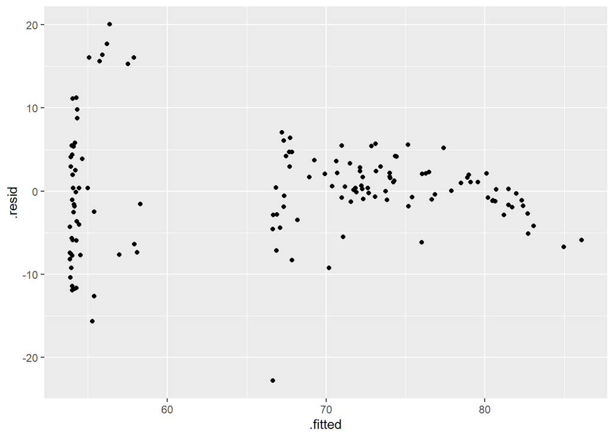

```r
ggplot(data = reg1_aug,
       mapping = aes(x = .fitted,
                     y = .resid)) +
    geom_point()
```

Or create a coefficient plot. (Don’t forget to add the `conf.int` parameter as `TRUE` to the `tidy()` call.) For `geom_errorbar` the `width` argument controls the size of the whiskers, for the `geom_errorbarh`, it is the `height =`. For added guidance to our audience, let’s create a significance dummy variable and sort our plot according to effect size.

```r
reg1_tidy
```

```
#> # A tibble: 7 x 7
#>   term              estimate     std.error statistic  p.value conf.low conf.high
#>   <chr>                <dbl>         <dbl>     <dbl>    <dbl>    <dbl>     <dbl>
#> 1 (Intercept)       5.37e+ 1 0.936            57.4   9.97e-97  5.19e+1   5.56e+1
#> 2 gdpPercap         3.48e- 4 0.0000572         6.09  1.13e- 8  2.35e-4   4.61e-4
#> 3 pop               9.59e-10 0.00000000393     0.244 8.07e- 1 -6.81e-9   8.72e-9
#> 4 continentAmericas 1.60e+ 1 1.67              9.59  6.20e-17  1.27e+1   1.93e+1
#> 5 continentAsia     1.26e+ 1 1.62              7.75  1.97e-12  9.36e+0   1.58e+1
#> 6 continentEurope   1.52e+ 1 1.97              7.73  2.20e-12  1.13e+1   1.91e+1
#> 7 continentOceania  1.66e+ 1 4.99              3.33  1.12e- 3  6.75e+0   2.65e+1
```

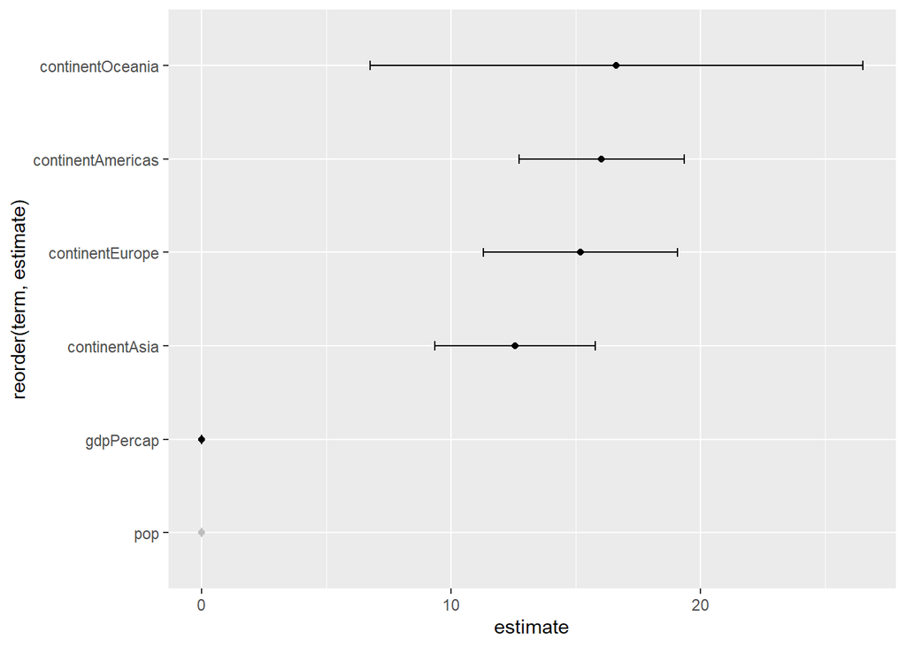

```r
reg1_tidy %>%
  mutate(significant = ifelse(p.value < 0.05, "yes", "no")) %>%
  filter(term != "(Intercept)") %>%
  ggplot(aes(reorder(term, estimate), estimate, color = significant)) +
  geom_point() +
  geom_errorbar(aes(ymin = conf.low, ymax = conf.high, width = 0.1)) +
  scale_color_manual(values = c("grey", "black"), guide = FALSE) +
  coord_flip()
```

# 3 Specialized applications

## 3.1 Network visualization

Let’s load our data from an edgelist. We are using the `tidygraph` `ggraph` packages, but both are heavily dependent on the `igraph` package which is one of the most powerful one for network analysis in R.

```r
# data
edges_got <- read_csv("https://raw.githubusercontent.com/melaniewalsh/sample-social-network-datasets/master/sample-datasets/game-of-thrones/got-edges.csv")
```

let’s create the network object and add some network statistics to our small social network

```r
soc_nw <- as_tbl_graph(edges_got, directed = FALSE) %>%
  activate(nodes) %>%
  mutate(
    centrality = centrality_eigen(),
    community = as.factor(group_infomap())
    )
```

We plot the network with the `ggraph()` function, that is a network oriented extension of `ggplot2`. The nodes and links are plotted separately with the `geom_edge_*` and `geom_node_*`. In this case `link` and `point`. The `"kk` layout stands for the Kamada Kawai layout. Other popular choice is the `"fr"` (Fruchterman Reingold)

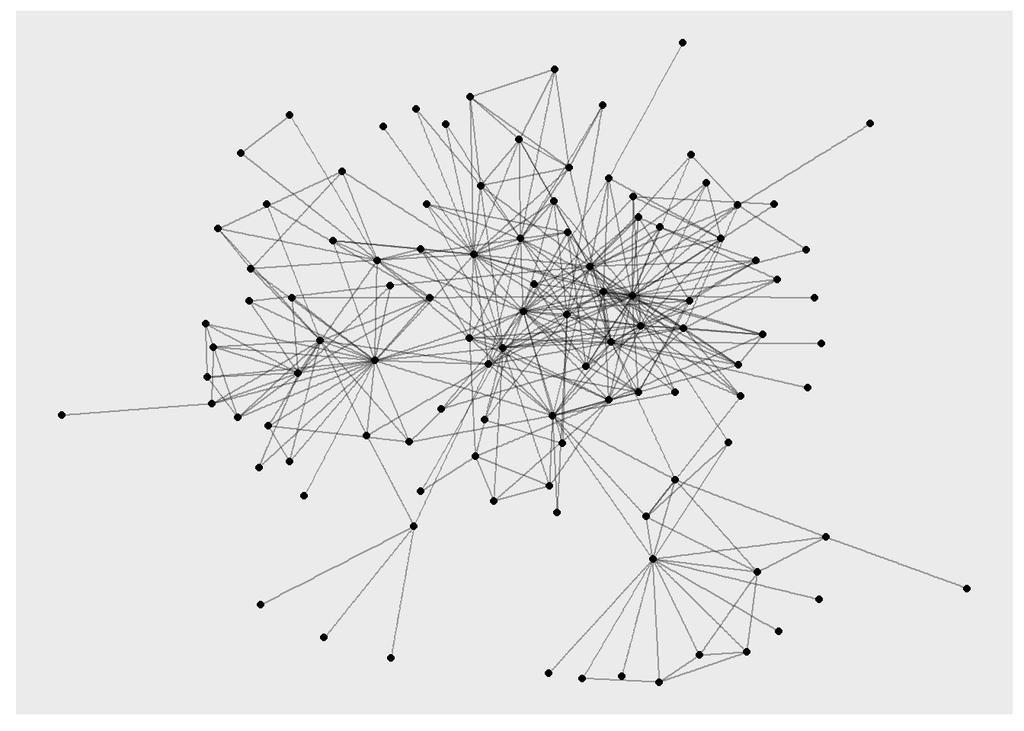

```r
ggraph(soc_nw, layout = "kk") +
  geom_edge_link(alpha = 0.35) +
  geom_node_point()
```

alternative with modifications to link and node attributes. Note the `theme_graph()` at the end.

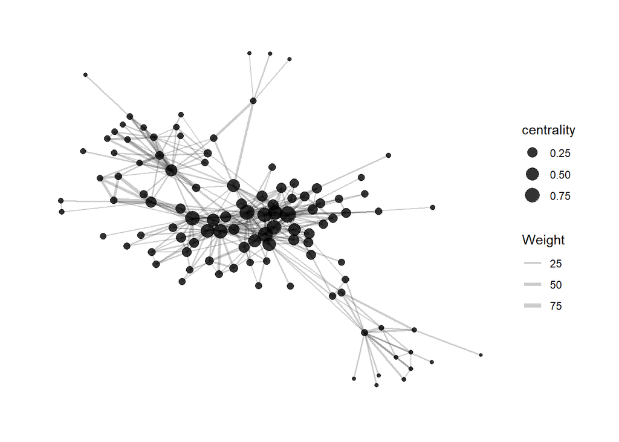

```r
ggraph(soc_nw, layout = "fr") +
  geom_edge_link(aes(width = Weight), alpha = 0.2) +
  scale_edge_width(range = c(0.5,2)) +
  geom_node_point(aes(size = centrality), alpha = 0.8) +
  theme_graph()
```

Final touch, let’s add the communities in the network and labels for our nodes.

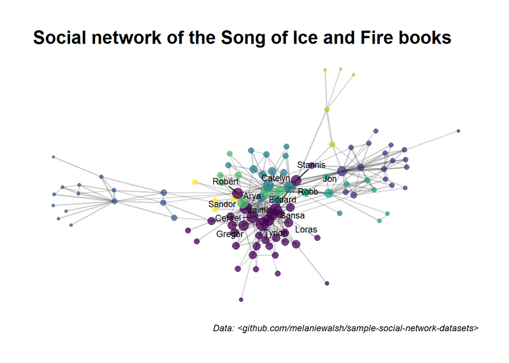

```r
ggraph(soc_nw, layout = "fr") +
  geom_edge_link(aes(width = Weight), alpha = 0.2, show_guide = FALSE) +
  scale_edge_width(range = c(0.5,1.5)) +
  geom_node_point(aes(size = centrality, color = community), alpha = 0.75, show_guide = FALSE) +
  geom_node_text(aes(label = if_else(centrality >= 0.35, name, NULL)), size = 3, repel = TRUE, show_guide = FALSE) +
  scale_color_viridis_d(option = "viridis") +
  labs(title = "Social network of the Song of Ice and Fire books",
       caption = "Data: <github.com/melaniewalsh/sample-social-network-datasets>") +
  theme_graph()
```

## 3.2 Maps

Two essential parts of creating a map with `ggplot2`: - shapefile which draws the map - some data that we want to plot over the map

Getting the map data from the `maps` package

```r
world <- map_data("world")
```

We can plot the empty map

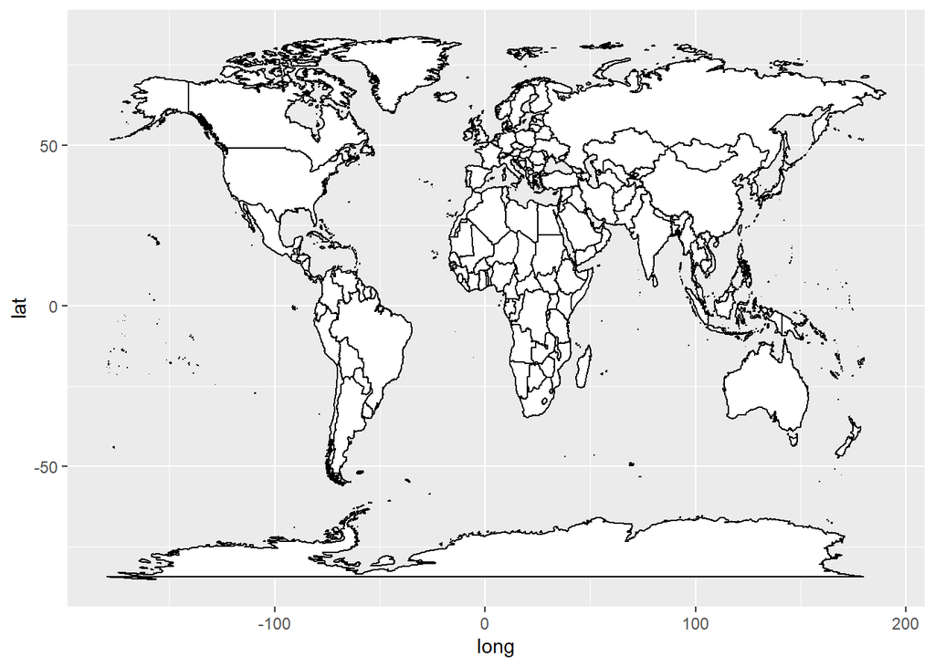

```r
ggplot(data = world,
       mapping = aes(x = long, y = lat, group = group)) +
  geom_polygon(fill = "white", color = "black") +
  coord_cartesian()
```

We can also subset the map data, just as we can with any other R object

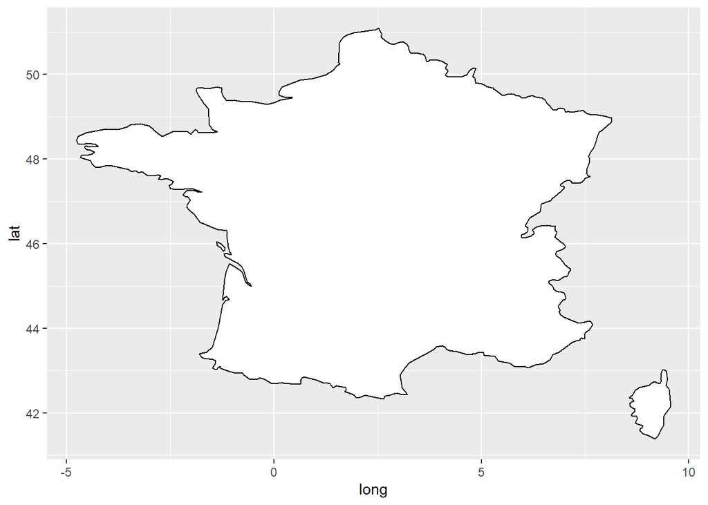

```r
# subsetting the world data
world_subset <- world[world$region == "France",]

ggplot(data = world_subset,
       mapping = aes(x = long, y = lat, group = group)) +
  geom_polygon(fill = "white", color = "black") +
  coord_cartesian()
```

We can add data to our map. We subset our gapminder data for the year 1977. Then add a new row that matches the region variable in the map data so we can merge the two dataset. (we also get rid of Antarctica, because of aesthetics)

```r
year_2000 <- gapminder %>%
  filter(year == 1977) %>%
  mutate(country = as.character(country))

# adding key variable for merge
year_2000$region <- year_2000$country

# merging the data and the map and getting rid of antarctica
world_data <- left_join(world, year_2000, by = "region") %>%
  filter(region != "Antarctica")
```

And now we can plot the map and data with the `geom_polygon()` and `coord_quickmap()`. I also made some modifications to the theme, so it looks better.

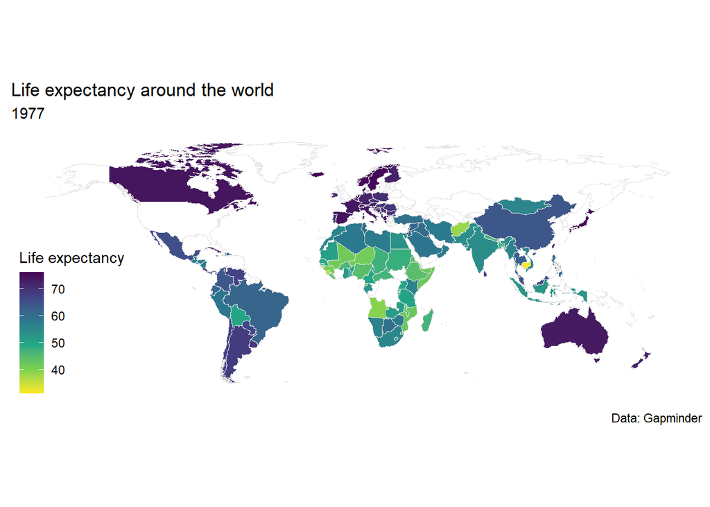

```r
ggplot(world_data, aes(long, lat, group = group, fill = lifeExp)) +
  geom_polygon(color = "gray90", size = 0.05 ) +
  coord_quickmap() +
  labs(
    fill = "Life expectancy",
    title = "Life expectancy around the world",
    subtitle = "1977",
    caption = "Data: Gapminder"
    ) +
  scale_fill_viridis_c(na.value = "white", direction = -1) +
  theme_bw() +
  theme(
    axis.line=element_blank(),
    axis.text=element_blank(),
    axis.ticks=element_blank(),
    axis.title=element_blank(),
    panel.background=element_blank(),
    panel.border=element_blank(),
    panel.grid=element_blank(),
    panel.spacing=unit(0, "lines"),
    plot.background=element_blank(),
    legend.justification = c(0,0),
    legend.position = c(0,0)
    )
```

### 3.2.1 example from the Eurostat package

The [vignette](https://ropengov.github.io/eurostat/articles/eurostat_tutorial.html#maps) contains the full tutorial on how to use the eurostat package to get data through the eurostat API. If you are interested check it out later.

```r
eurobarometer_raw <- read_stata("data/ZA6963_v1-0-0.dta")

q8_eurobar <- eurobarometer_raw %>%
  select(isocntry, qa8a_10) %>%
  mutate(
    trust_in_eu = factor(qa8a_10, levels = c(1,2,3), labels = c("Tend to trust", "Tend not to trust", "Don't know")),
    geo = case_when(isocntry == "DE-W" ~ "DE",
                    isocntry == "DE-E" ~ "DE",
                    isocntry == "GB-GBN" ~ "UK",
                    isocntry == "GB-NIR" ~ "UK",
                    TRUE ~ isocntry)
  ) %>%
  tidyr::drop_na()
```

Then we see what is the proportion of people trusting the EU in each member state.

```r
# share of respondent who trust the EU
q8_country_trust <- q8_eurobar %>%
  group_by(geo, qa8a_10) %>%
  summarise(n = sum(n())) %>%
  ungroup() %>%
  filter(qa8a_10 == 1)

# total number of respondents
q8_total <- q8_eurobar %>%
  group_by(geo) %>%
  summarise(sum = n())

# merging the two dataset to calculate the share of people trusting the EU
q8_map_merge <- left_join(q8_country_trust, q8_total, by = "geo") %>%
  mutate(
    trust_pct = round((n / sum) * 100),
    trust_cat = factor(case_when(trust_pct >= 50 ~ 1,
                                 trust_pct < 50  ~ 0))
    )
```

Finally, we download the EU shapefile via the eurostat package.

```r
eu_map <- eurostat::get_eurostat_geospatial(resolution = "60") %>%
  filter(LEVL_CODE == 0)
```

To plot the data on the map we have to combine the shapefile and the survey data with a `left_join`.

```r
eu_map_plot <- left_join(eu_map, q8_map_merge, by = "geo")
```

Now we are ready to plot! We use `geom_sf()` to fill the countries with our data and `coord_sf` to have the map projected between the given coordinates. For the color scale, let’s use the viridis scale. Altough we use the `theme_minimal` we can make additional changes to the theme by adding the `theme()` call last.

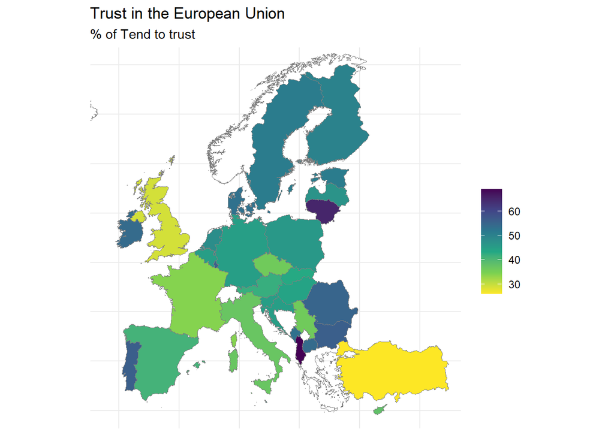

```r
ggplot(eu_map_plot) +
  geom_sf(aes(fill = trust_pct), color= "grey50", size = 0.1) +
  coord_sf(xlim=c(-12,44), ylim=c(35,70)) +
  scale_fill_viridis_c(na.value = "white", direction = -1, name = NULL) +
  labs(
    title = "Trust in the European Union",
    subtitle = "% of Tend to trust"
    ) +
  theme_minimal() +
  theme(axis.text = element_blank())
```

If we want to add arbitrary points to the map, we can do that by specifying the longitudinal and latitudinal coordinates.

```r
long <- c(10)
lat <- c(50)
my_city <- as.data.frame(cbind(long,lat))
```

Then just plot over our map with the `geom_point()`

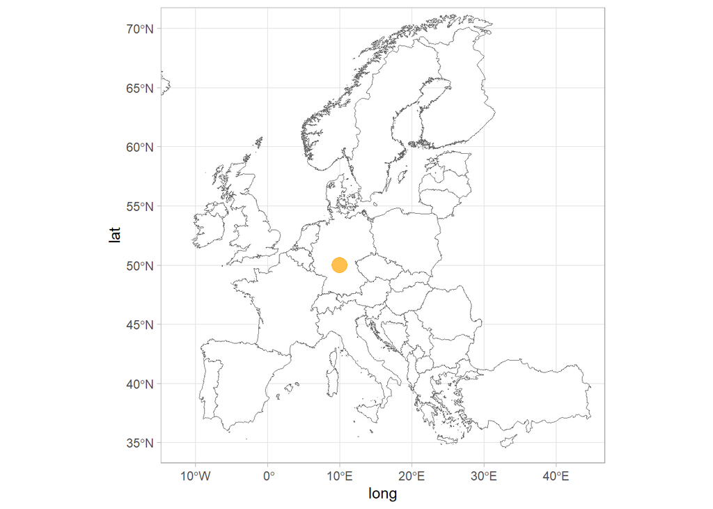

```r
ggplot(data=eu_map_plot) +
  geom_sf(fill= "white", color="dim grey", size=.1) +
  geom_point(data = my_city, aes(x = long, y = lat), color = "orange", size = 5, alpha = 0.7) +
  theme_light() +
  coord_sf(xlim=c(-12,44), ylim=c(35,70))
```

## 3.3 Dendograms

It is common practice to apply hierarchical clustering to data to discover similar (or dissimilar) clusters. Such similarity measures can be visualized by a tree-like plot, called dendograms. For this brief excercise, we will use the European 2007 cross section of the gapminder dataset and see how hierarchical clustering looks like.

```r
gapminder_eu <- gapminder_cs %>%
  filter(continent == "Europe") %>%
  select(-continent, country) %>%
  as.data.frame()
```

As a first step we create a distance matrix from our dataset. We’ll put the country names variable as rownames so the matrix transformation will preserve the labels. Please note that having rownames in your data is generally considered a bad practice and here we are doing it only for the sake of the exercise.

```r
rownames(gapminder_eu) <- gapminder_cs %>%
  filter(continent == "Europe") %>%
  pull(country)
```

We create a distance object, called `d` with the `dist()` function, where we can specify that we want to compute the euclidean distance. In the next step, we carry out the hierarchical clustering algorithm using complete linkages.

```r
d <- dist(gapminder_eu, method = "euclidean")
complete_cluster <- hclust(d, method = "complete")
```

Then we `plot`:

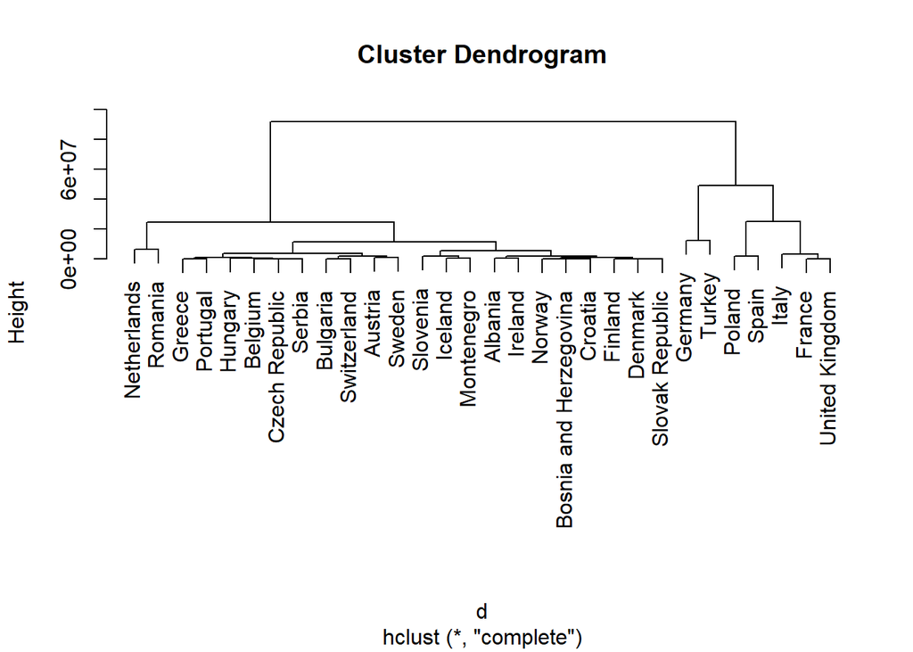

```r
plot(complete_cluster)
```